## Mechanisms of positive plant interactions.

The aim of this study was to conceptualize the mechanistic pathways of the nurse-plant syndrome by life-form and to identify the implications of positive plant–plant interactions forlandscape and evolutionary ecology. It is becoming increasingly apparent that future studies of the nurse-plant syndrome must decouple and consider multiple mechanisms of interaction to explain the processes that influence community structure, particularly in high-stress conditions, given a changing climate and potential shifts in biodiversity.

[Filazzola, A., & Lortie, C. J. (2014). A systematic review and conceptual framework for the mechanistic pathways of nurse plants. Global Ecology and Biogeography, 23(12), 1335-1345.](http://onlinelibrary.wiley.com/doi/10.1111/geb.12202/full)

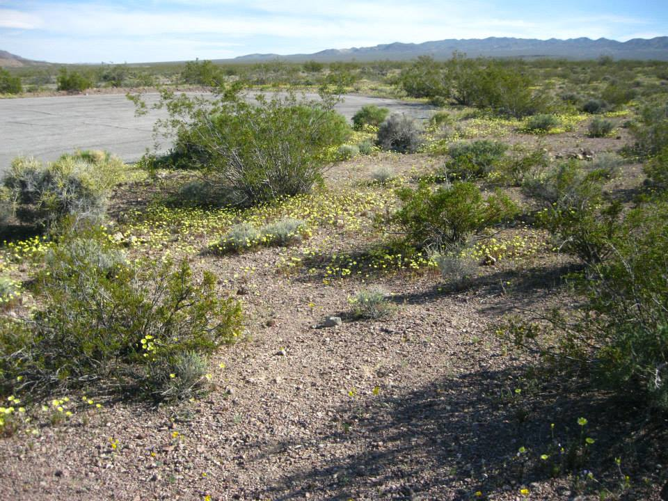

[ecoblender](http://ecoblender.org)

### Global studies map

```r
locations<-read.csv("locations.csv")
str(locations)
```

```
## 'data.frame':    221 obs. of  2 variables:
##  $ lat: num  24.1 20.5 34.4 39.1 39.5 ...
##  $ lon: num  -110 -156 -120 -120 -119 ...
```

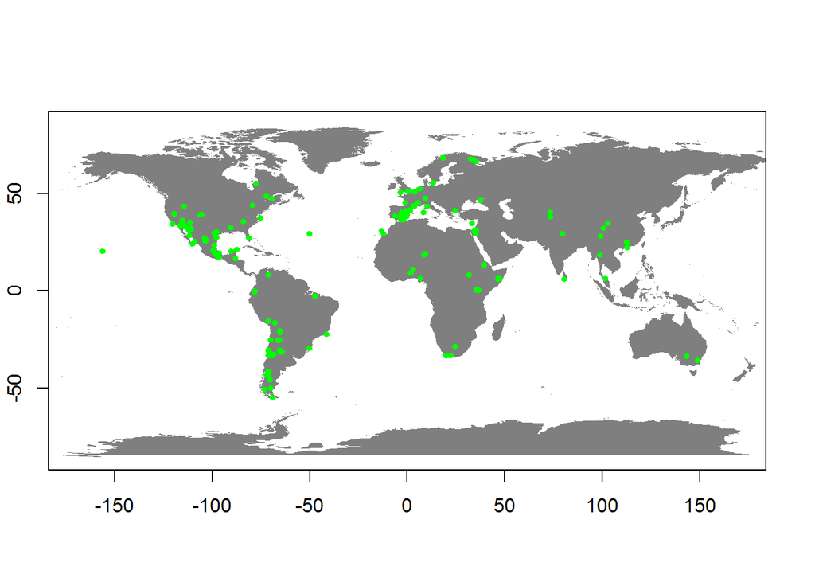

```r
library(maps)
library(mapdata)

par(mar=c(0,0,0,0))
map("world", fill=T, col="grey50", border=FALSE,  xlim=c(-180,180), ylim=c(-90,90))
axis(1)
axis(2)
box()
points(locations$lon,locations$lat, pch=19, col="green", cex=0.6)
```

### Facilitation by biome

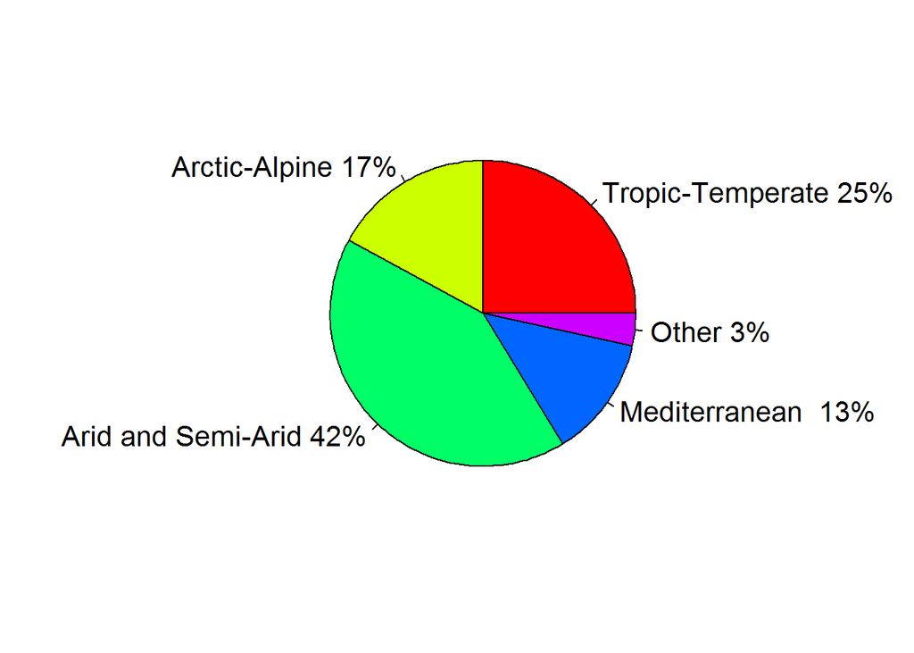

```r
#Environment Tested

lbls <- c("Tropic-Temperate","Arctic-Alpine","Arid and Semi-Arid","Mediterranean ","Other")
enviro <- c(66,45,110,34,9)
percent <- round(enviro/sum(enviro)*100)
lbls <- paste (lbls, percent)
lbls <- paste(lbls,"%",sep="")
pie(enviro,labels=lbls, cex=1.3, col=rainbow(length(lbls)))
```

```r
m5 <- chisq.test(enviro)
m5
```

```
##
##  Chi-squared test for given probabilities
##
## data:  enviro
## X-squared = 109.45, df = 4, p-value < 2.2e-16
```

```r
m5$stdres
```

```
## [1]  2.031010 -1.200142  8.801042 -2.892650 -6.739259
```

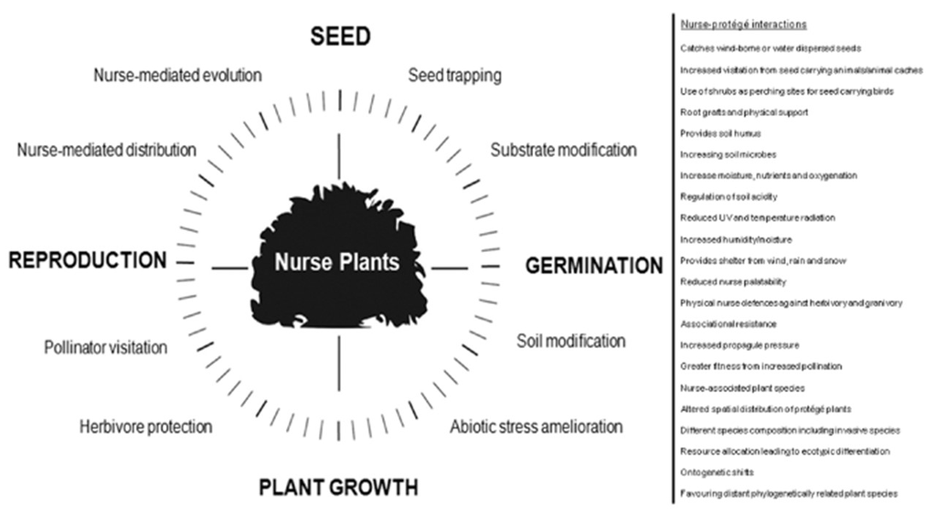

[figure link](https://figshare.com/articles/A_conceptual_framework_of_nurse_plant_mechanisms/861164)

The relative frequency of each ecological hypothesis and nurse mechanism tested per study was compared using Pearson’s chi-squared tests. To contrast the frequencies of nurse mechanisms and ecological theories, we used a Pearson’s chi-squared test and compared the proportion for each grouping with the resulting standardized residuals as post hoc tests

### Hypotheses & mechanisms tested

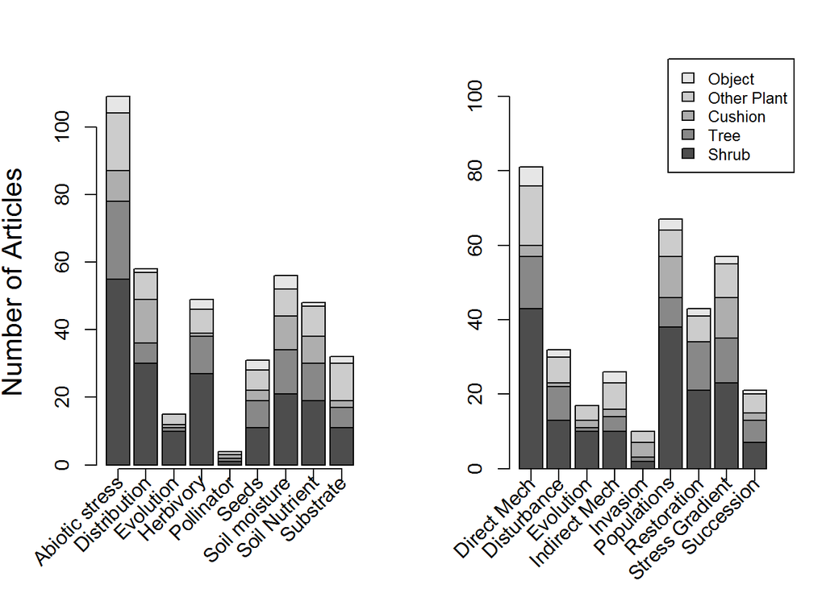

```r
par(mfrow = c(1,2))

plot2 <- barplot(dat2, xlab="", xaxt="n", ylab="Number of Articles", cex.lab=1.4, cex.names=1.2)
axis(side=1, at=plot2, labels=FALSE)
text(plot2,par("usr")[3] - 3, srt = 45, adj = 1,labels=xlab2,xpd = TRUE)

plot1 <- barplot(dat1, xlab="", xaxt='n', ylim=c(0,100),  cex.lab=1.4, cex.names=1.2, legend.text=TRUE, args.legend= list(x=12, y=110, cex=0.8, legend=legend))
axis(side=1, at=plot1, labels=FALSE)
text(plot1,par("usr")[3] - 3, srt = 45, adj = 1,labels=xlab1,xpd = TRUE)
```

```r
#chi-square and post-hoc
m3 <- chisq.test(Hypo)
m3
```

```
##
##  Chi-squared test for given probabilities
##
## data:  Hypo
## X-squared = 120.86, df = 8, p-value < 2.2e-16
```

```r
m3$stdres
```

```
##     Direct Mech     Disturbance       Evolution   Indirect Mech
##        7.046682       -1.240216       -3.777021       -2.254938
##        Invasion     Populations     Restoration Stress Gradient
##       -4.960864        4.678997        0.620108        2.987793
##      Succession
##       -3.100540
```

```r
m4 <- chisq.test(Mech)
m4
```

```
##
##  Chi-squared test for given probabilities
##
## data:  Mech
## X-squared = 164.69, df = 8, p-value < 2.2e-16
```

```r
m4$stdres
```

```
## Abiotic stress   Distribution      Evolution      Herbivory     Pollinator
##     10.2098778      2.1160368     -4.7081820      0.6877120     -6.4539124
##          Seeds  Soil moisture  Soil Nutrient      Substrate
##     -2.1689378      1.7986313      0.5290092     -2.0102350
```

We also separated the number of studies associated with each ecological hypothesis based on nurse life-form and conducted a Kruskal–Wallis test followed by post hoc multiple comparisons tests (pgirmess package in R). To determine if the proportion of nurse life-forms was similar between ecological hypotheses, each one was treated as a percentage of the total number of nurse-plant studies and a one-way ANOVA was conducted between life-forms. Tukey’s honestly significant difference tests were used for these post hoc comparisons.

### Pairwise mechanisms contrasts

```r
fit3 <- kruskal.test(studies~nurse, data=concepttest)
summary(fit3)
```

```
##           Length Class  Mode
## statistic 1      -none- numeric
## parameter 1      -none- numeric
## p.value   1      -none- numeric
## method    1      -none- character
## data.name 1      -none- character
```

```r
kruskalmc(studies~nurse + concept, data=concepttest) ## post-hoc contrast of kurskal.wallis
```

```
## Multiple comparison test after Kruskal-Wallis
## p.value: 0.05
## Comparisons
##                   obs.dif critical.dif difference
## Cushion-Object  5.5555556     17.37945      FALSE
## Cushion-Other  10.1666667     17.37945      FALSE
## Cushion-Shrub  18.8333333     17.37945       TRUE
## Cushion-Tree    9.3333333     17.37945      FALSE
## Object-Other   15.7222222     17.37945      FALSE
## Object-Shrub   24.3888889     17.37945       TRUE
## Object-Tree    14.8888889     17.37945      FALSE
## Other-Shrub     8.6666667     17.37945      FALSE
## Other-Tree      0.8333333     17.37945      FALSE
## Shrub-Tree      9.5000000     17.37945      FALSE
```

```r
# Proprotionality between studies

fit5 <- aov(concept~nurse, data=propor)
summary(fit5)
```

```
##             Df Sum Sq Mean Sq F value   Pr(>F)
## nurse        4 0.7590 0.18975   22.23 1.01e-09 ***
## Residuals   40 0.3414 0.00854
## ---
## Signif. codes:  0 '***' 0.001 '**' 0.01 '*' 0.05 '.' 0.1 ' ' 1
```

```r
TukeyHSD(fit5)
```

```
##   Tukey multiple comparisons of means
##     95% family-wise confidence level
##
## Fit: aov(formula = concept ~ nurse, data = propor)
##
## $nurse
##                       diff         lwr         upr     p adj
## Object-Cushion -0.07796103 -0.20235365  0.04643158 0.3933869
## Other-Cushion   0.08542302 -0.03896959  0.20981564 0.3031059
## Shrub-Cushion   0.30967627  0.18528366  0.43406888 0.0000001
## Tree-Cushion    0.06327461 -0.06111800  0.18766723 0.5981608
## Other-Object    0.16338406  0.03899144  0.28777667 0.0047937
## Shrub-Object    0.38763730  0.26324469  0.51202992 0.0000000
## Tree-Object     0.14123565  0.01684304  0.26562826 0.0191243
## Shrub-Other     0.22425325  0.09986063  0.34864586 0.0000694
## Tree-Other     -0.02214841 -0.14654102  0.10224420 0.9860429
## Tree-Shrub     -0.24640166 -0.37079427 -0.12200904 0.0000137
```